# Dinucleotide content of human selected sequences Analysis Report

Emmanuel Cazottes

28 January, 2026

Notebook to compute cliff’s delta of the di nucleotide content of the human selected sequences, top/bottom 10% selected sequences and randomly selected sequences against the AL pool.

Di-nucleotide content is computed using the polygraph package and normqlized to sequence length.

# Data import and preprocessing

```r
obs.freq.selected = read.table("sequence_analysis/diNuclContent.selected.tsv", header = T, sep = "\t")
obs.freq.top_n_bottom = read.table("sequence_analysis/diNuclContent.top_n_bottom_10.tsv", header = T, sep = "\t")
obs.freq.alpool = read.table("sequence_analysis/diNuclContent.pool.tsv", header = T, sep = "\t")
```

Add labels and sequence names from the original sequence file. The rows are conserved, I checked it by computing the di-nucleotide content for a couple of single sequences and it perfectly matches with the values in the big file.

```r
labels = read.table("sequences/master_output.tsv", col.names = c("seqid","seq","method"), sep = "\t", header = F)
labels = labels[,-2] # Remove the sequence column

# Format the labels
no.seed = str_remove(labels$method, "(_[1-5]_1x60)|(_[1-5]_3x20)")
labels$model.arch = unlist(lapply(str_split(no.seed, "_"), function(x){x[length(x)]}))
labels$al.method = unlist(lapply(str_split(no.seed, "_(attn|rnn|cnn)"), function(x){x[1]}))
labels$no.seed = no.seed

#Merge the dinucl with the labels
dinucl.selected.labelled = cbind(obs.freq.selected,labels)

#Remove the sequence ID column from the selected pool
dinucl.selected.labelled = dinucl.selected.labelled[,-17]
```

Annotation of the top and bottom sequences

```r
labels.tnb = read.table("sequences/human_top_n_bottom_10.tsv", col.names = c("seqid","seq","method"), sep = "\t", header = F)
labels.tnb = labels.tnb[,-2] # Remove the sequence column
#Replacing 1x60 by 60k to fit the data annotation
labels.tnb$method = gsub("1x60", "60k", labels.tnb$method)
labels.tnb$model.arch = "tnb"
labels.tnb$al.method = labels.tnb$method

labels.tnb$no.seed = labels.tnb$method

#Bind the di-nucleotid content and the labels
tnb.labelled = cbind(obs.freq.top_n_bottom, labels.tnb)
#Remove the sequence ID column from the selected pool
tnb.labelled = tnb.labelled[,-17]
```

Random selection

```r
random.sampling = function(df, nb.rnd, nb.sample){
  value.list = list()
  size = seq(1, nrow(df), by=1)
  i= 1
  while (i <= nb.sample) {
    rnd.size = sample(size, nb.rnd)
    value.list[[i]] = df[rnd.size,]
    value.list[[i]]$method = paste0("RandomSampling_",i)
    value.list[[i]]$model.arch = paste0("RandomSampling_",i)
    value.list[[i]]$al.method = paste0("RandomSampling_",i)
    value.list[[i]]$no.seed = paste0("RandomSampling_",i)
    i = i +1
  }
  return(value.list)
}

obs.freq.rnd = random.sampling(obs.freq.alpool,20000,15 )
```

Labelling for the AL pool and the training pool

```r
obs.freq.alpool$method = "AL pool"
obs.freq.alpool$model.arch = "AL pool"
obs.freq.alpool$al.method = "AL pool"
obs.freq.alpool$no.seed = "AL pool"

# Bind everything together
dinucl.labelled = rbind(dinucl.selected.labelled,tnb.labelled,obs.freq.alpool)
#Split by method
dinucl.labelled = group_split(dinucl.labelled, no.seed)
```

# Cliff’s delta

Compute the cliff’s delta on the distribution of each dinucleotide per sequence for each architecture/model pair and the AL pool. The question being do we have a different dinucleotide contents

## Selected sequences

```r
library(effectsize)

cliff.d.selected = lapply(dinucl.labelled, function(x){
  dinucl.cliff.d = data.frame(matrix(ncol = 4, nrow = 16))
  colnames(dinucl.cliff.d) = c("cliff.d", "CI","CI.low", "CI.high")
  for(i in c(1:16)){
 dinucl.cliff.d[i,] = cliffs_delta(x[[i]], obs.freq.alpool[[i]])
  }
  dinucl.cliff.d$di.nucl = colnames(obs.freq.alpool)[c(1:16)]
  dinucl.cliff.d$model.arch = unique(x$model.arch)
  dinucl.cliff.d$al.method = unique(x$al.method)

  return(dinucl.cliff.d)
})
```

Everything to a dataframe for plotting

```r
cliff.d.selected.df = do.call("rbind", cliff.d.selected)
summary(cliff.d.selected.df$cliff.d)
```

```
##       Min.    1st Qu.     Median       Mean    3rd Qu.       Max.
## -0.2880551 -0.0347069 -0.0045850 -0.0009305  0.0585564  0.3201255
```

## Cliff’s delta for randomly selected sequences

Cliff’s delta for randomly selected sequences

```r
cliff.d.rnd = lapply(obs.freq.rnd, function(x){
  dinucl.cliff.d = data.frame(matrix(ncol = 16, nrow = 1))
  for(i in c(1:16)){
    dinucl.cliff.d[1,i] = cliffs_delta(x[[i]], obs.freq.alpool[[i]])[,1]
    }
  colnames(dinucl.cliff.d) = colnames(obs.freq.alpool)[c(1:16)]

  return(dinucl.cliff.d)
})

cliff.d.rnd.mean = data.frame(cliff.d =apply(do.call("rbind",cliff.d.rnd),2,mean),
                              CI=0.95,
                              CI.low=0,
                              CI.high=1,
                              di.nucl=colnames(obs.freq.alpool)[c(1:16)],
                              model.arch="Random selection",
                              al.method="Random selection")
```

```r
#Subset by number of rounds
cliff.d.selected.df.1x60 = cliff.d.selected.df[grep(pattern = "60k",cliff.d.selected.df$al.method),]
cliff.d.selected.df.3x20 = cliff.d.selected.df[grep(pattern = "60k",cliff.d.selected.df$al.method,invert = T),]
```

# Plots

```r
heat.plot = function(data.plot, tittle.plot){
  heatmap.plot = ggplot(data.plot, aes(x=di.nucl, y=al.method, fill=cliff.d))+
  geom_tile(color = "black", linewidth = 0.5)+
    xlab("")+
  ylab("")+
    labs(title = tittle.plot, fill = "Cliff's delta")+
  scale_fill_gradient2(
    low = "blue",
    mid = "white",
    high = "red",
    midpoint = 0,
    limits = c(-0.35, 0.35),
    breaks = seq(-0.35, 0.35, by = 0.1),
    labels = sprintf("%.2f", seq(-0.35, 0.35, by = 0.1))
  ) +
  coord_fixed()+
    theme(axis.text = element_text(size=7),plot.margin = margin(5, 5, 5, 5, "mm"))

  return(heatmap.plot)
}
```

## 3x20 rounds

```r
#For the 3x20 rounds
control.3x20 = subset(cliff.d.selected.df, al.method %in% c("diversity_3x20_bottom10",
                                                            "uncertainty_3x20_bottom10",
                                                            "diversity_3x20_top1010",
                                                            "uncertainty_3x20_top1010",
                                                            "AL pool"))
control.3x20 = rbind(control.3x20,cliff.d.rnd.mean)
#Rename labels for plotting
control.3x20$al.method = gsub("diversity_3x20_bottom10", "Least diverse", control.3x20$al.method)
control.3x20$al.method = gsub("uncertainty_3x20_bottom10", "Least uncertain", control.3x20$al.method)
control.3x20$al.method = gsub("diversity_3x20_top1010", "Most diverse", control.3x20$al.method)
control.3x20$al.method = gsub("uncertainty_3x20_top1010", "Most uncertain", control.3x20$al.method)

#Order labels for plotting
control.3x20$al.method = factor(control.3x20$al.method,
                                levels = c("Most diverse", "Least diverse", "Most uncertain","Least uncertain" ,"Random selection","AL pool"))

control.3x20.heat = heat.plot(control.3x20, "Human - 3x20")
```

```r
#3x20
cnn.heat.3x20 = heat.plot(subset(cliff.d.selected.df.3x20, model.arch=="cnn"), "Human - CNN - 3x20")
rnn.heat.3x20= heat.plot(subset(cliff.d.selected.df.3x20, model.arch=="rnn"), "Human - RNN - 3x20")
attn.heat.3x20= heat.plot(subset(cliff.d.selected.df.3x20, model.arch=="attn"), "Human - ATTN - 3x20")
```

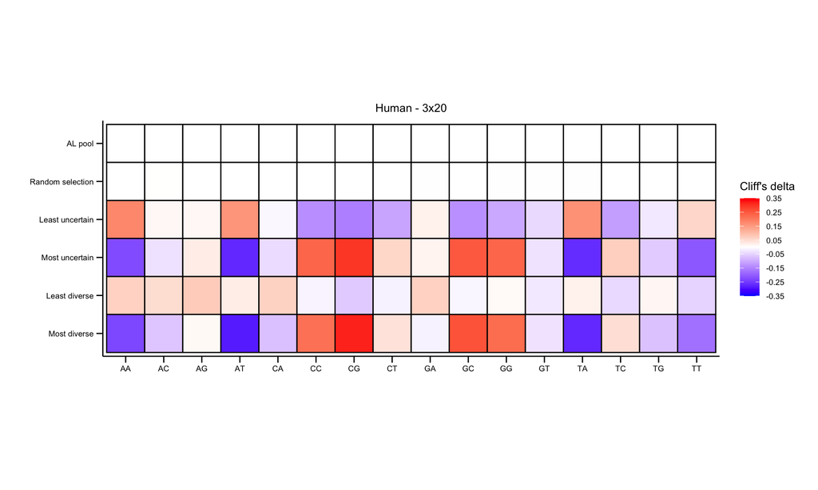

Selected sequences dinucleotide analysis 3x20

```r
print(control.3x20.heat)
```

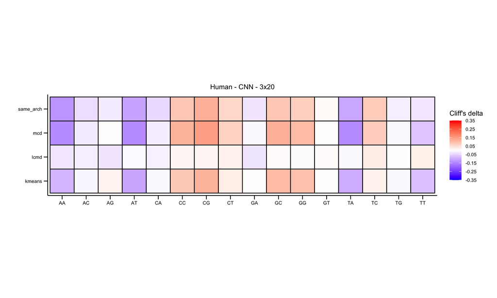

Selected sequences dinucleotide analysis 3x20

```r
print(cnn.heat.3x20)
```

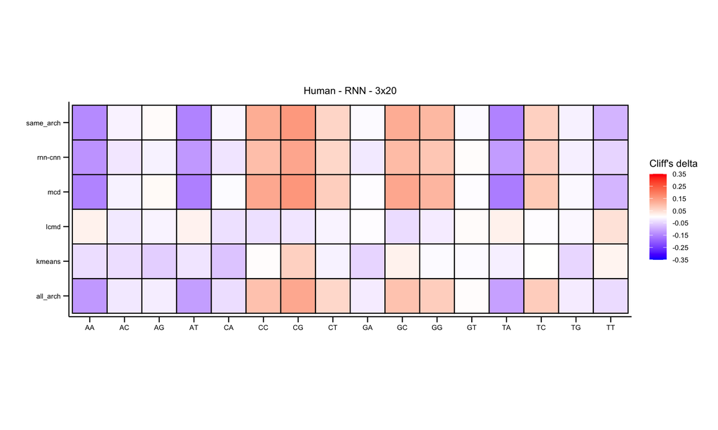

Selected sequences dinucleotide analysis 3x20

```r
print(rnn.heat.3x20)
```

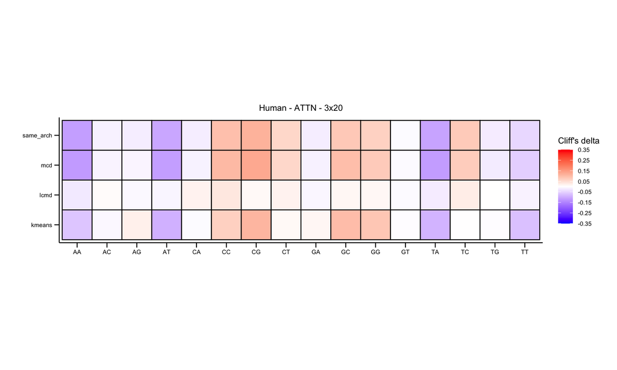

Selected sequences dinucleotide analysis 3x20

```r
print(attn.heat.3x20)
```

## 1x60 rounds

Same formatting for control sequences 60k

```r
#For the 1x60k round
control.1x60 = subset(cliff.d.selected.df, al.method %in% c("diversity_60k_bottom10",
                                                            "uncertainty_60k_bottom10",
                                                            "diversity_60k_top1010",
                                                            "uncertainty_60k_top1010",
                                                            "AL pool"))

control.1x60 = rbind(control.1x60,cliff.d.rnd.mean)
#Rename labels for plotting
control.1x60$al.method = gsub("diversity_60k_bottom10", "Least diverse", control.1x60$al.method)
control.1x60$al.method = gsub("uncertainty_60k_bottom10", "Least uncertain", control.1x60$al.method)
control.1x60$al.method = gsub("diversity_60k_top1010", "Most diverse", control.1x60$al.method)
control.1x60$al.method = gsub("uncertainty_60k_top1010", "Most uncertain", control.1x60$al.method)

#Order labels for plotting
control.1x60$al.method = factor(control.1x60$al.method,
                                levels = c("Most diverse", "Least diverse", "Most uncertain","Least uncertain" ,"Random selection","AL pool"))

control.1x60.heat = heat.plot(control.1x60, "Human - 1x60")
```

heatmaps for selected sequences

```r
cnn.heat.1x60 = heat.plot(subset(cliff.d.selected.df.1x60, model.arch=="cnn"), "Human - CNN - 1x60")
rnn.heat.1x60 = heat.plot(subset(cliff.d.selected.df.1x60, model.arch=="rnn"), "Human - RNN - 1x60")
attn.heat.1x60 = heat.plot(subset(cliff.d.selected.df.1x60, model.arch=="attn"), "Human - ATTN - 1x60")
```

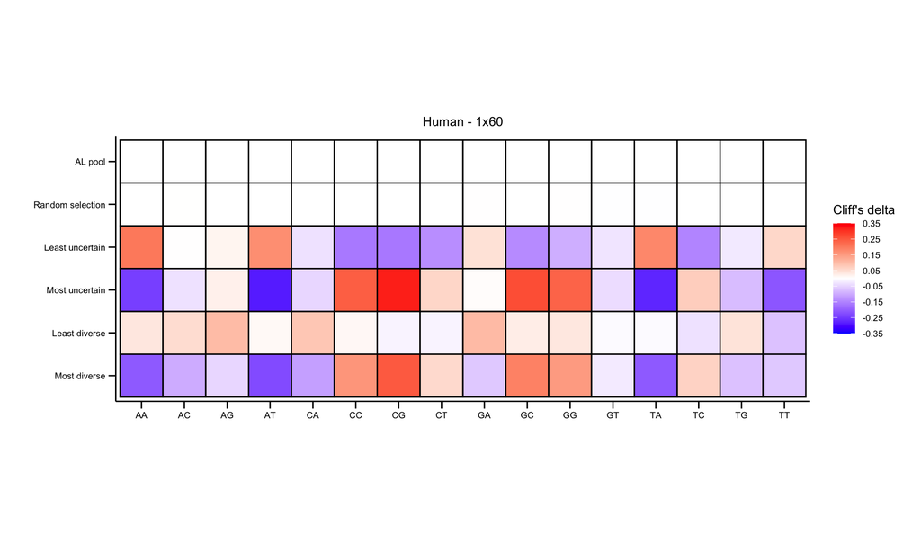

Selected sequences dinucleotide analysis 1x60

```r
print(control.1x60.heat)
```

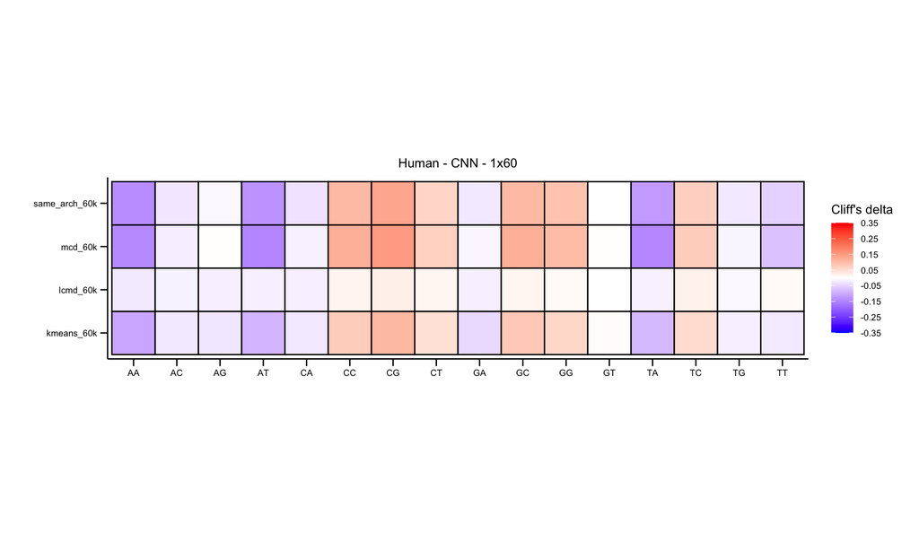

Selected sequences dinucleotide analysis 1x60

```r
print(cnn.heat.1x60)
```

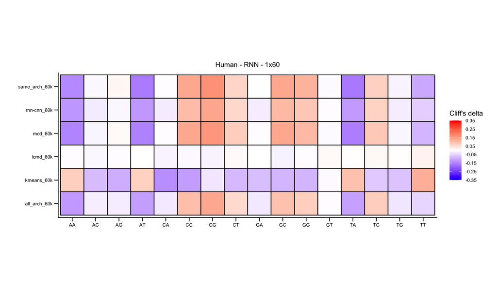

Selected sequences dinucleotide analysis 1x60

```r
print(rnn.heat.1x60)
```

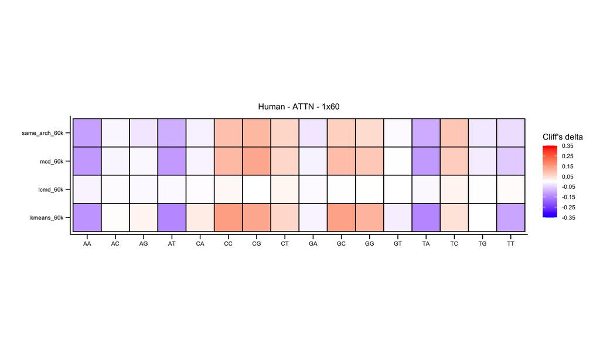

Selected sequences dinucleotide analysis 1x60

```r
print(attn.heat.1x60)
```